# Pile jacking example in Abaqus

## 6.2 Boundary conditions, loads and predefined fields

Within each step, boundary conditions and loads will be applied. Therefore, the `Load module` has to be selected, either by the drop-down menu above the viewport or by right clicking on `Loads` or `BCs` within a step and choosing `Switch context`. Each step will have its own set of loads and boundary conditions.

Some options like Interactions, Contact, Loads and BCs are available in each step and can be found on a higher level in the model tree below the Steps entry. Within the steps, those options can be defined, turned on and turned off. They are saved within the higher level entries, where they can be defined globally or deleted.

To define boundary conditions, either select `BC->Create` in the main menu, right click on `BCs` within the inital step in the model tree and select `Create` or use the quick start symbol (). The Create Boundary Condition dialog will open (cf. figure 6.2).

The first boundary condition to be defined in the *Initial step* will be the fixation of the pile in all directions. Thus a `Displacement/Rotation` boundary condition should be applied. It can be more convenient to create two boundary conditions, one to fix all directions but the vertical one (which is valid for the whole simulation) and one to fix the downward movement in the initial step.[^19]

The movement of the pile is constrained to the movement of the reference point, so all loads/boundary conditions of the pile will be defined for *setRP* of *instPile*. The corresponding dialogs for the permanent fixation (*fixPile*) are shown in figure 6.2.

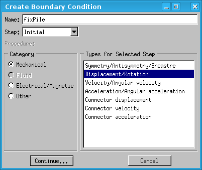

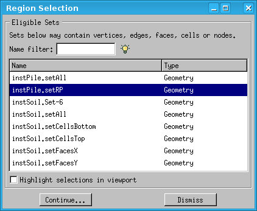

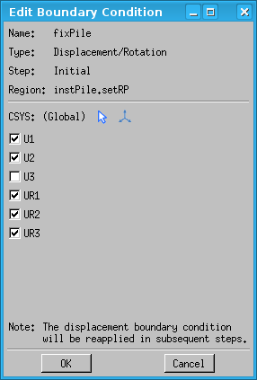

```python
mdb.models['PileJackingModel'].DisplacementBC(name='fixPile', createStepName='Initial',
   amplitude=UNSET, distributionType=UNIFORM, fieldName='', region=instPile.sets['setRP'],
   localCsys=None, u1=SET, u2=SET, u3=UNSET, ur1=SET, ur2=SET, ur3=SET);
```

Figure 6.2: Boundary condition dialogs. After choosing to create a boundary condition, a type must be selected (left hand side), the geometry chosen (middle) and the values selected (right hand side).

When using the default (global) coordinate system CSYS: (GLOBAL), the directions will match the standard coordinates: $1=x$, $2=y$, $3=z$.

Additionally create another `Displacement/Rotation` boundary condition named *fixDownwardMovement* in the intial step, which only fixates `U3`.

```python
mdb.models['PileJackingModel'].DisplacementBC(name='fixDownwardMovement', amplitude=UNSET,
   createStepName='Initial', distributionType=UNIFORM, fieldName='', localCsys=None,
   region=instPile.sets['setRP'], u1=UNSET, u2=UNSET, u3=SET, ur1=UNSET, ur2=UNSET, ur3=UNSET);
```

In the *PileJacking step* the pile should be driven down 3 m. The duration for this step is 3 s, so the downward velocity has to be 1 m/s. Since the soil itself is only 4 m high in this example, the boundary effects will notably influence the result. Normally, there is much more space around the pile to minimize all boundary effects.

Right click on `fixDownwardMovement (Propagated)` in the current step’s boundary conditions in the model tree and select `Deactivate` to deactivate this boundary condition from this step on forward. This can also be done in the Boundary Condition manager, which can be accessed either by the quick start symbol () next to the create boundary condition icon or by selection `BC->Manager` in the main menu.

Create a `Velocity/Angular velocity` boundary condition for *setPileRP* named *drivePile* and enter the downward velocity `V3: -1`.

```python
mdb.models['PileJackingModel'].boundaryConditions['fixDownwardMovement'].deactivate(
   'PileJacking');
mdb.models['PileJackingModel'].VelocityBC(name='drivePile', createStepName='PileJacking',
   amplitude=UNSET, distributionType=UNIFORM, fieldName='', region=instPile.sets['setRP'],
   localCsys=None, v1=UNSET, v2=UNSET, v3=-1.0, vr1=UNSET, vr2=UNSET, vr3=UNSET);
```

For the Eulerian material to be able to move through the mesh, a `Predefined Fields` entry has to be created in the initial step to assign the material for the soil. Either select the quick start symbol (), choose `Predefined Field->Create` in the main menu or right click on `Predefined Fields` in the initial step and choose `Create`. The Create Predefined Field window will open as shown in figure 6.3.

Choose Material assignment in the initial step and select the Eulerian instance. Assign `setCellsBottom` with soil material and `setCellsTop` with void to represent sand in the bottom part of the soil element and empty space above.

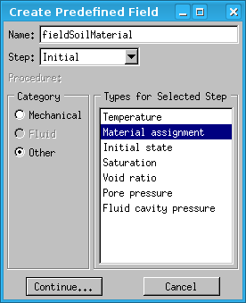

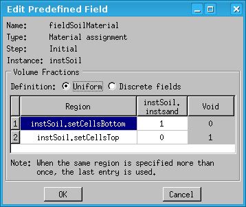

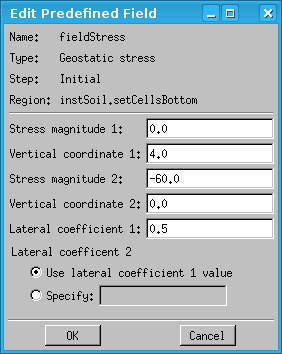

```python
mdb.models['PileJackingModel'].MaterialAssignment(name='fieldSoilMaterial',
   instanceList=(instSoil, ), assignmentList=((instSoil.sets['setCellsBottom'], (1, )),
   (instSoil.sets['setCellsTop'], (0, ))), useFields=False);
```

Figure 6.3: Create Predefined Field window on the left hand side and Edit Predefined Field window for Material assignment in the middle. The Edit Predefined Field window for Geostatic stress is shown on the right hand side.

Another predefined field can be used to model the geostatic stress within the sand material. This definition has to be applied in the initial step, too. Choose `Mechanical` as category to be able to select `Geostatic stress`. Choose the *setCellsBottom* set and configure the parameters to have 0 kPa at the upper plane of the sand material volume and 60 kPa at the lower boundary (choose $-60$ since it is pressure and not tension). The lateral coefficient can be set to $K_0=1-\sin{\left(\varphi\right)}\approx 0.5$ (cf. right hand side of figure 6.3).

```python
mdb.models['PileJackingModel'].GeostaticStress(lateralCoeff1=0.5, lateralCoeff2=None,
   name='fieldStress', region=instSoil.sets['setCellsBottom'], vCoord1=4.0, vCoord2=0.0,
   stressMag1=0.0, stressMag2=-60.0);
```

The movement of the sand at the soil boundaries has to be restricted, so that the material cannot flow out of the soil body. Since Eulerian material can move through the mesh, displacement boundary conditions aren’t useful here. Therefore, three `Velocity/Angular velocity boundary` conditions are created and applied on the surfaces with the same normal direction. Sets of the boundary surfaces were created in chapter 2, so that e. g. a boundary condition restricting the movement in $x$-direction (*fixSoilBoundaryX*) can be applied on the corresponding set (*setFacesX*).

After applying boundary conditions for $x$-direction, $y$-direction and the bottom of the soil, no material should be able to flow in or out of the model except the top. The result can be seen in figure 6.4.

[figure not shown]

Figure 6.4: Abaqus window when creating soil surface boundary conditions. The surface region normal to the $x$-direction, where the *fixSoilBoundaryX* boundary condition is applied, is highlighted.

```python
mdb.models['PileJackingModel'].VelocityBC(name='fixSoilBoundaryX', createStepName='Initial',
   amplitude=UNSET, distributionType=UNIFORM, fieldName='', localCsys=None,
   region=instSoil.sets['setFacesX'],
   v1=0.0, v2=UNSET, v3=UNSET, vr1=UNSET, vr2=UNSET, vr3=UNSET);
mdb.models['PileJackingModel'].VelocityBC(name='fixSoilBoundaryY', createStepName='Initial',
   amplitude=UNSET, distributionType=UNIFORM, fieldName='', localCsys=None,
   region=instSoil.sets['setFacesY'],
   v1=UNSET, v2=0.0, v3=UNSET, vr1=UNSET, vr2=UNSET, vr3=UNSET);
mdb.models['PileJackingModel'].VelocityBC(name='fixSoilBoundaryZ', createStepName='Initial',
   amplitude=UNSET, distributionType=UNIFORM, fieldName='', localCsys=None,
   region=instSoil.sets['setFacesBottom'],
   v1=UNSET, v2=UNSET, v3=0.0, vr1=UNSET, vr2=UNSET, vr3=UNSET);
```

Similar to boundary conditions loads can be applied. Right click on `Loads` and choose `Create` in the model tree, select `Load->Create` in the main menu or click on its quick start symbol (). The Create Load window will open and like creating boundary conditions, the type of load, the region to apply to and the values need to be selected.

In this example, gravity will be applied to the whole model in the *Preparation step* by its gravitational acceleration 9.81 m/s$^2$ in the (negative) $z$-direction (cf. figure 6.5).

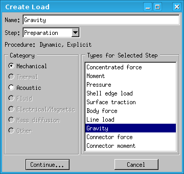

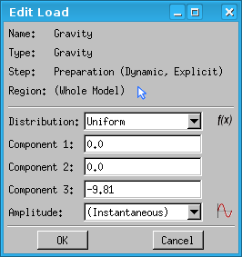

```python
mdb.models['PileJackingModel'].Gravity(comp3=-9.81, createStepName='Preparation',
   distributionType=UNIFORM, field='', name='Gravity');
```

Figure 6.5: The Create Load window on the left hand side and the Edit Load window for a gravitational force on the right hand side.

## 6.3 Output requests

Like boundary conditions, loads and predefined fields, output requests can be issued (in the `Step module`) either in each step or in general. A default Field Output Request and a default History Output Request will be present. Sometimes it may be useful to create new output requests, either by right clicking on the appropriate name in the model tree and choosing `Create`, by browsing `Output->` in the main menu and choosing `Create` or by using the quick start symbol for a new field output request () or history output request (). As a rule of thumb, anything visible in the whole 3D-Model must be requested as Field Output and all further investigated time history/results of single points and sets should be requested as History Output.

A field output saves the requested states for certain point(s) in time for all elements. A history output saves the requested states for all time increments but only for the selected element(s).

The present output requests can be edited by the output manager, which is accessible by the quick start symbol next to the output request creation () by the model tree or the main menu (cf. figure 6.6).

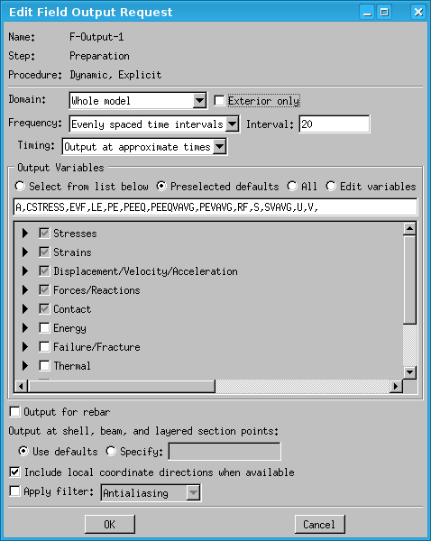

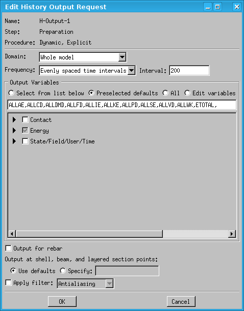

Figure 6.6: Default field output request and history output request window.

In this example especially the flow of the material should be observed, which is saved in the *Eulerian Volume Fraction* (EVF). By default and among others, the *Volume-averaged Stresses* (SVAVG), the *Displacements* (U) and the *Accelerations* (A) for the soil and the *Displacements* (U) and *Reaction Forces* (RF) for the pile (i. e. its reference point) will be recorded. Other entries of the field output are of minor importance here and could be removed from the calculation.

Consider which field outputs are necessary since they can generate big output databases very fast. Issuing more output requests at more nodes/elements and increasing the outputs per seconds can also increase the computation time.

If only reference points or a few geometric objects should be observed, it is useful to create separate output requests for them. Choose the objects/sets as `Domain` instead of the whole model (see figure 6.6).

# 7 Meshing

Before creating and submitting the job the model has to be meshed. This could also be done much earlier (e. g. before assembling the parts), but has to be after all geometric changes are already applied.

Every time the geometry of a part is changed or partitions are added/removed, the mesh needs to be redone.

There are two meshing viewports: Meshing can be done per part (dependent meshes) or for the assembled model (independent meshes). To mesh dependent meshes per part, first change to the `Part module` and then to the `Mesh module`. Otherwise Abaqus will try to mesh the whole assembled model, which—in this case—isn’t desired.

Meshing is used to create nodes for calculating and evaluating the simulation. The meshing can be influenced by seeding the parts as a whole () and edgewise () to get the right amount of seeds per edge/part. Both options can also be accessed by the main menu or the model tree.

Most times it is favorable to have cube-like elements (structured hex) without any dominant direction.

If this kind of mesh can be applied, the element will be colored green. Otherwise if only a sweeped mesh can be applied, the element will be yellow. But if a hex mesh is intended but can’t be applied out of the box, partitions can help to divide the part in more suitable subparts. This can also be done to get a finer mesh locally. To change the mesh type (if possible), open the Assign Mesh Controls window ().

A coarser mesh has less nodes and needs less time to calculate. At the same time, the result might not be as precise as desired or not available at interesting points.

First, the pile should be meshed. If not done already, switch to the `Mesh module` and activate the pile part. Seed the whole part and choose an approximate global size of 1.0 (cf. left hand side of figure 7.1). Apply and mesh the part by the quick start symbol (), the model tree or the main menu.

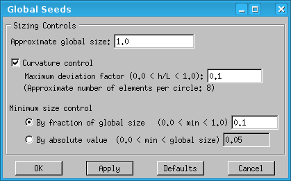

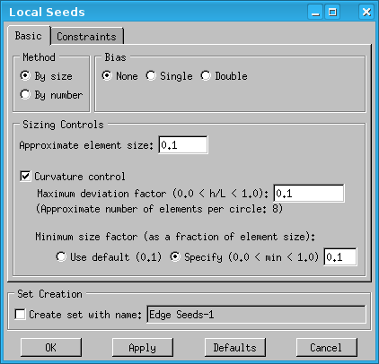

```python
partPile.seedPart(deviationFactor=0.1, minSizeFactor=0.1, size=1.0);
partPile.generateMesh();
```

Figure 7.1: Global Seeds window and Local Seeds window.

The meshing of the soil part will be a bit different. After making the soil element active, a global seed with an approximate global size of 0.4 will be set. Now the edges close to the pile jacking volume will be seeded () as shown in the bottom of figure 7.2. Choose in the Local Seeds window (cf. right hand side of figure 7.1) an approximate element size of 0.1.[^20] Apply the mesh to the geometry to have a finer mesh region where the material flow is important and a coarser one everywhere else.

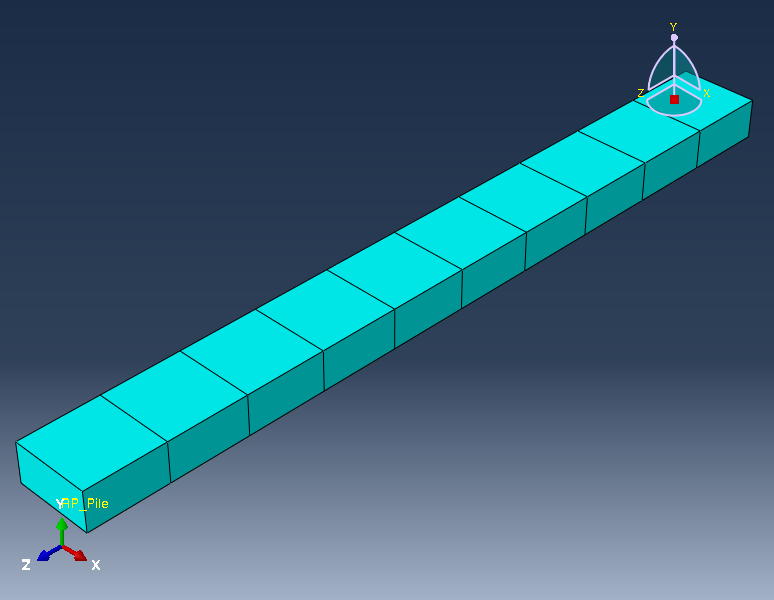

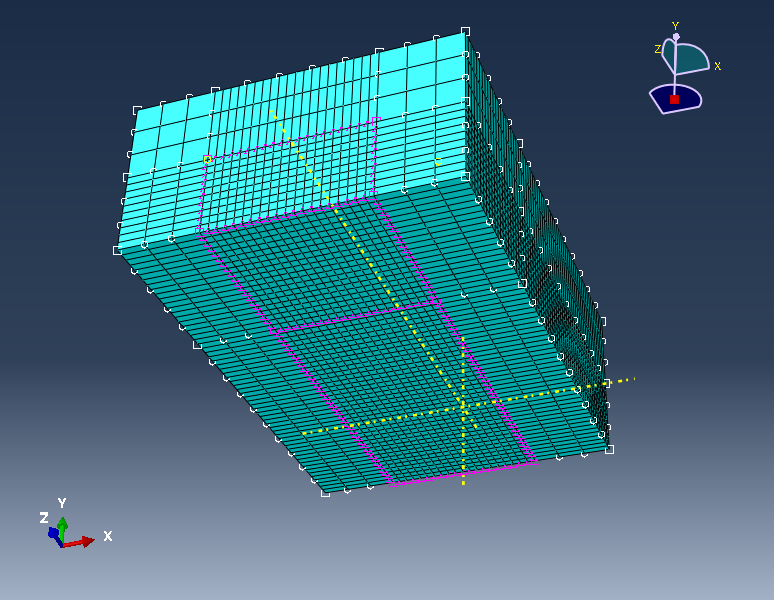

```python
partSoil.seedPart(deviationFactor=0.1, minSizeFactor=0.1, size=0.4);
fineredges = partSoil.edges[0:0];
for singleedge in partSoil.edges:
   if ((singleedge.pointOn[0][1] <= 0.0) and (abs(singleedge.pointOn[0][0]) <= 1.0)):
      fineredges += partSoil.edges[singleedge.index:singleedge.index+1];
#
partSoil.seedEdgeBySize(constraint=FINER, deviationFactor=0.1, edges=fineredges,
   minSizeFactor=0.1, size=0.1);
partSoil.generateMesh();
```

Figure 7.2: Viewport of meshed pile (above) and meshed soil element (below). The viewport of the soil element also shows the global seeds (white circles) and the manually set edge seeds (purple triangles lines).

# 8 Getting the job done

## 8.1 Job creation and submission

All preparations are done and a new job can be created in the `Job module`. Either right click on `Jobs` and choose `Create`, select `Job->Create` in the main menu or use the quick start symbol (). The Create Job window will open as shown in figure 8.1 and the new job has to be named (this will be the name of the input file). Give a short description in the Edit Job window and for longer/critical calculations, always change the precision in the `Precision` tab to Double Precision. If using a user routine (e. g. user defined material), the file needs to be added in the `General` tab.

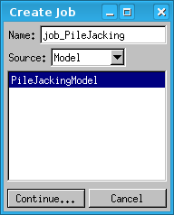

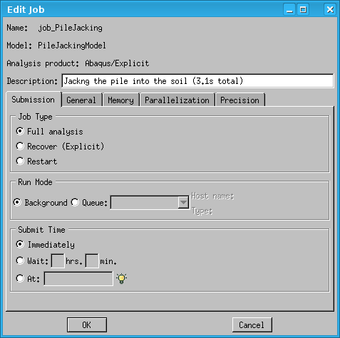

Figure 8.1: Create Job window (left hand side) and Edit Job window (right hand side).

Right click on the newly created job and choose `Write Input` to create an input file. After creating a job a stand-alone text file with all configuration is written—the input file `<model>.inp`. Abaqus can run this file to do the simulation.

```python
mdb.Job(activateLoadBalancing=False, atTime=None, contactPrint=OFF,
   description='Jacking the pile into the soil (3.1s total)', echoPrint=OFF,
   explicitPrecision=DOUBLE_PLUS_PACK, historyPrint=OFF, memory=90, memoryUnits=PERCENTAGE,
   model='PileJackingModel', modelPrint=OFF, multiprocessingMode=DEFAULT,
   name='job_PileJacking', nodalOutputPrecision=FULL, numCpus=1, numDomains=1,
   parallelizationMethodExplicit=DOMAIN, queue=None, resultsFormat=ODB, scratch='',
   type=ANALYSIS, userSubroutine='', waitHours=0, waitMinutes=0);
mdb.jobs['job_PileJacking'].writeInput(consistencyChecking=OFF);
```

After creating a job and before submission, it is advisable to run a data check. Either select `Job->Data Check->` in the main menu or right click on the job and choose `Data Check`. Most formal errors in the model can be found and will be reported. A successfull data check is a prerequisite for running the simulation.

Always run a data check before submission to exclude most formal errors before starting the simulation.

Data checks and simulations always create additional status files, especially `<model>.dat` and `<model>.sta`. Both text files can be used to gather information about the calculation as well as warnings and error messages. They can also be accessed by right clicking on the job name and choosing `Monitor`. If problems are encountered, try to correct them and rerun the data check/simulation.

Small jobs can be run in the Abaqus CAE gui while bigger jobs are preferably outsourced to a computation cluster (if available).

## 8.2 Concerning Input files

This section will show and discuss the input file created by this tutorial. The only difference is that a much coarser mesh is used for the soil body than described in chapter 7 to prevent an unnecessary data overhead for the discussion. The mesh applied to the pile has an approximate global size of 2, the mesh for the soil consists only of the global seeds with a size of 1 resulting in a model shown in figure 8.2. The input file looks like this:

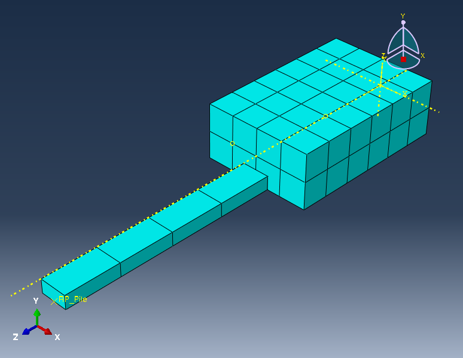

Figure 8.2: Same model with a very coarse mesh—for discussion of the input file only.

The Heading is named after the job description and line 2 includes the original name of this job file (`<model>.inp`) and the model name. Starting in line 8, actions within the `Part module` are shown.

[output not shown]

Giving meaningful names to elements does not only look nice, it helps to find and understand elements and structures. In line 9 to 34 the coordinates of the 24 nodes of the *Pile* are numbered and described, which are defined by the (coarse) mesh.

```
*Part, name=Pile
*Node
      1,          0.5,         0.25,          10.
      2,          0.5,        -0.25,          10.
      3,          0.5,         0.25,           8.
      4,          0.5,        -0.25,           8.
      5,          0.5,         0.25,           6.
      6,          0.5,        -0.25,           6.
      7,          0.5,         0.25,           4.
      8,          0.5,        -0.25,           4.
      9,          0.5,         0.25,           2.
     10,          0.5,        -0.25,           2.
     11,          0.5,         0.25,           0.
     12,          0.5,        -0.25,           0.
     13,         -0.5,         0.25,          10.
     14,         -0.5,        -0.25,          10.
     15,         -0.5,         0.25,           8.
     16,         -0.5,        -0.25,           8.
     17,         -0.5,         0.25,           6.
     18,         -0.5,        -0.25,           6.
     19,         -0.5,         0.25,           4.
     20,         -0.5,        -0.25,           4.
     21,         -0.5,         0.25,           2.
     22,         -0.5,        -0.25,           2.
     23,         -0.5,         0.25,           0.
     24,         -0.5,        -0.25,           0.
```

The element type is a short version of **C**ontinuous **3D** element with **8** nodes and **R**educed integration.

```
*Element, type=C3D8R
1, 13, 14, 16, 15,  1,  2,  4,  3
2, 15, 16, 18, 17,  3,  4,  6,  5
3, 17, 18, 20, 19,  5,  6,  8,  7
4, 19, 20, 22, 21,  7,  8, 10,  9
5, 21, 22, 24, 23,  9, 10, 12, 11
```

Line 41 marks the 25th node (`0, -0.25, 10`). It is used as internal reference point in 42–43 and as a set in 49–50. The set of the whole part is defined in line 45–48.

```
*Node
     25,           0.,        -0.25,          10.
*Nset, nset=Pile-RefPt_, internal
25,
*Nset, nset=setAll, generate
  1,  24,   1
*Elset, elset=setAll, generate
 1,  5,  1
*Nset, nset=setRP
 25,
```

The section *secPile* is created to assign steel material to the element. The definition of the *Pile* part is finished in line 54.

```
** Section: secPile
*Solid Section, elset=setAll, material=steel
,
*End Part
**
```

The definition for the *Soil* part starts here. It is essentially the same as for the *Pile* part above. Line 58–162 list and describe the coordinates of the 105 nodes defined by the coarse mesh.

```
*Part, name=Soil
*Node
      1,           2.,           0.,           4.
      2,           2.,           0.,           0.
      3,           2.,           1.,           0.
      4,           2.,           1.,           4.
      5,           1.,           0.,           4.
      6,           1.,           0.,           0.
      7,           1.,           1.,           0.
      8,           1.,           1.,           4.
      9,          -1.,           0.,           0.
     10,          -1.,           1.,           0.
     11,          -1.,           0.,           4.
     12,          -1.,           1.,           4.
     13,          -2.,           0.,           6.
     14,          -1.,           0.,           6.
     15,          -1.,           1.,           6.
     16,          -2.,           1.,           6.
     17,          -2.,           0.,           4.
     18,          -2.,           1.,           4.
     19,           2.,           0.,           6.
     20,           2.,           1.,           6.
     21,           1.,           0.,           6.
     22,           1.,           1.,           6.
     23,          -2.,           1.,           0.
     24,          -2.,           0.,           0.
     25,          -1.,          -1.,           0.
     26,          -1.,          -1.,           4.
     27,          -2.,          -1.,           4.
     28,          -2.,          -1.,           0.
     29,          -1.,          -1.,           6.
     30,           1.,          -1.,           4.
     31,           1.,          -1.,           6.
     32,           2.,          -1.,           6.
     33,           2.,          -1.,           4.
     34,          -2.,          -1.,           6.
     35,           1.,          -1.,           0.
     36,           2.,          -1.,           0.
     37,           2.,           0.,           3.
     38,           2.,           0.,           2.
     39,           2.,           0.,           1.
     40,           2.,           1.,           1.
     41,           2.,           1.,           2.
     42,           2.,           1.,           3.
     43,           1.,           0.,           3.
     44,           1.,           0.,           2.
     45,           1.,           0.,           1.
     46,           1.,           1.,           1.
     47,           1.,           1.,           2.
     48,           1.,           1.,           3.
     49,           0.,           0.,           0.
     50,           0.,           1.,           0.
     51,           0.,           0.,           4.
     52,           0.,           1.,           4.
     53,          -1.,           1.,           1.
     54,          -1.,           1.,           2.
     55,          -1.,           1.,           3.
     56,          -1.,           0.,           3.
```

```
     57,          -1.,           0.,           2.
     58,          -1.,           0.,           1.
     59,          -2.,           1.,           5.
     60,          -2.,           0.,           5.
     61,          -1.,           1.,           5.
     62,          -1.,           0.,           5.
     63,           2.,           0.,           5.
     64,           2.,           1.,           5.
     65,           1.,           0.,           5.
     66,           1.,           1.,           5.
     67,           0.,           0.,           6.
     68,           0.,           1.,           6.
     69,          -2.,           1.,           3.
     70,          -2.,           1.,           2.
     71,          -2.,           1.,           1.
     72,          -2.,           0.,           1.
     73,          -2.,           0.,           2.
     74,          -2.,           0.,           3.
     75,          -1.,          -1.,           1.
     76,          -1.,          -1.,           2.
     77,          -1.,          -1.,           3.
     78,          -2.,          -1.,           3.
     79,          -2.,          -1.,           2.
     80,          -2.,          -1.,           1.
     81,          -1.,          -1.,           5.
     82,           0.,          -1.,           4.
     83,           1.,          -1.,           5.
     84,           0.,          -1.,           6.
     85,           2.,          -1.,           5.
     86,          -2.,          -1.,           5.
     87,           0.,          -1.,           0.
     88,           1.,          -1.,           1.
     89,           1.,          -1.,           2.
     90,           1.,          -1.,           3.
     91,           2.,          -1.,           3.
     92,           2.,          -1.,           2.
     93,           2.,          -1.,           1.
     94,           0.,           0.,           1.
     95,           0.,           0.,           2.
     96,           0.,           0.,           3.
     97,           0.,           1.,           1.
     98,           0.,           1.,           2.
     99,           0.,           1.,           3.
    100,           0.,           0.,           5.
    101,           0.,           1.,           5.
    102,           0.,          -1.,           5.
    103,           0.,          -1.,           3.
    104,           0.,          -1.,           2.
    105,           0.,          -1.,           1.
```

The element type of the *Soil* part is a short version of **E**ulerian **C**ontinuous **3D** element with **8** nodes and **R**educed integration.

```
*Element, type=EC3D8R
 1,  5, 43, 48,  8,  1, 37, 42,  4
 2, 43, 44, 47, 48, 37, 38, 41, 42
 3, 44, 45, 46, 47, 38, 39, 40, 41
 4, 45,  6,  7, 46, 39,  2,  3, 40
 5, 45, 94, 97, 46,  6, 49, 50,  7
 6, 94, 58, 53, 97, 49,  9, 10, 50
 7, 44, 95, 98, 47, 45, 94, 97, 46
 8, 95, 57, 54, 98, 94, 58, 53, 97
```

```
 9, 43, 96, 99, 48, 44, 95, 98, 47
10, 96, 56, 55, 99, 95, 57, 54, 98
11,  5, 51, 52,  8, 43, 96, 99, 48
12, 51, 11, 12, 52, 96, 56, 55, 99
13, 60, 62, 61, 59, 13, 14, 15, 16
14, 17, 11, 12, 18, 60, 62, 61, 59
15, 21, 65, 66, 22, 19, 63, 64, 20
16, 65,  5,  8, 66, 63,  1,  4, 64
17,  11,  51,  52,  12,  62, 100, 101,  61
18,  51,   5,   8,  52, 100,  65,  66, 101
19,  62, 100, 101,  61,  14,  67,  68,  15
20, 100,  65,  66, 101,  67,  21,  22,  68
21, 74, 56, 55, 69, 17, 11, 12, 18
22, 73, 57, 54, 70, 74, 56, 55, 69
23, 72, 58, 53, 71, 73, 57, 54, 70
24, 24,  9, 10, 23, 72, 58, 53, 71
25,  9, 58, 72, 24, 25, 75, 80, 28
26, 58, 57, 73, 72, 75, 76, 79, 80
27, 57, 56, 74, 73, 76, 77, 78, 79
28, 56, 11, 17, 74, 77, 26, 27, 78
29,  14,  62, 100,  67,  29,  81, 102,  84
30,  62,  11,  51, 100,  81,  26,  82, 102
31,  67, 100,  65,  21,  84, 102,  83,  31
32, 100,  51,   5,  65, 102,  82,  30,  83
33,  5, 65, 83, 30,  1, 63, 85, 33
34, 65, 21, 31, 83, 63, 19, 32, 85
35, 11, 62, 60, 17, 26, 81, 86, 27
36, 62, 14, 13, 60, 81, 29, 34, 86
37,  11,  56,  96,  51,  26,  77, 103,  82
38,  56,  57,  95,  96,  77,  76, 104, 103
39,  57,  58,  94,  95,  76,  75, 105, 104
40,  58,   9,  49,  94,  75,  25,  87, 105
41,  51,  96,  43,   5,  82, 103,  90,  30
42,  96,  95,  44,  43, 103, 104,  89,  90
43,  95,  94,  45,  44, 104, 105,  88,  89
44,  94,  49,   6,  45, 105,  87,  35,  88
45,  6, 45, 88, 35,  2, 39, 93, 36
46, 45, 44, 89, 88, 39, 38, 92, 93
47, 44, 43, 90, 89, 38, 37, 91, 92
48, 43,  5, 30, 90, 37,  1, 33, 91
```

The set for the whole part is defined in line 212–215, *setCellsTop* in 216–221 and *setCellsBottom* in 222–230.

```
*Nset, nset=setAll, generate
   1,  105,    1
*Elset, elset=setAll, generate
  1,  48,   1
*Nset, nset=setCellsTop
   1,  4,  5,  8, 11, 12, 13, 14, 15, 16,  17,  18,  19, 20, 21, 22
  26, 27, 29, 30, 31, 32, 33, 34, 51, 52,  59,  60,  61, 62, 63, 64
  65, 66, 67, 68, 81, 82, 83, 84, 85, 86, 100, 101, 102
*Elset, elset=setCellsTop
 13, 14, 15, 16, 17, 18, 19, 20, 29, 30, 31, 32, 33, 34, 35, 36
*Nset, nset=setCellsBottom
   1,  2,  3,  4,  5,  6,  7,  8,   9,  10,  11, 12, 17, 18, 23, 24
  25, 26, 27, 28, 30, 33, 35, 36,  37,  38,  39, 40, 41, 42, 43, 44
  45, 46, 47, 48, 49, 50, 51, 52,  53,  54,  55, 56, 57, 58, 69, 70
  71, 72, 73, 74, 75, 76, 77, 78,  79,  80,  82, 87, 88, 89, 90, 91
  92, 93, 94, 95, 96, 97, 98, 99, 103, 104, 105
*Elset, elset=setCellsBottom
  1,  2,  3,  4,  5,  6,  7,  8,  9, 10, 11, 12, 21, 22, 23, 24
 25, 26, 27, 28, 37, 38, 39, 40, 41, 42, 43, 44, 45, 46, 47, 48
```

The sets created to apply the boundary conditions on the soil are defined/saved here.

```
*Nset, nset=setFacesX
  1,  2,  3,  4, 13, 16, 17, 18, 19, 20, 23, 24, 27, 28, 32, 33
 34, 36, 37, 38, 39, 40, 41, 42, 59, 60, 63, 64, 69, 70, 71, 72
 73, 74, 78, 79, 80, 85, 86, 91, 92, 93
*Elset, elset=setFacesX
  1,  2,  3,  4, 13, 14, 15, 16, 21, 22, 23, 24, 25, 26, 27, 28
 33, 34, 35, 36, 45, 46, 47, 48
*Nset, nset=setFacesY
   3,   4,   7,   8,  10,  12, 15, 16, 18, 20, 22, 23, 25, 26, 27, 28
  29,  30,  31,  32,  33,  34, 35, 36, 40, 41, 42, 46, 47, 48, 50, 52
  53,  54,  55,  59,  61,  64, 66, 68, 69, 70, 71, 75, 76, 77, 78, 79
  80,  81,  82,  83,  84,  85, 86, 87, 88, 89, 90, 91, 92, 93, 97, 98
  99, 101, 102, 103, 104, 105
*Elset, elset=setFacesY, generate
  1,  48,   1
*Nset, nset=setFacesBottom
  2,  3,  6,  7,  9, 10, 23, 24, 25, 28, 35, 36, 49, 50, 87
*Elset, elset=setFacesBottom
  4,  5,  6, 24, 25, 40, 44, 45
```

The section *secSoil* is created to assign the Eulerian material sand to the element. The definition of this part is done in line 255.

```
** Section: secSoil
*Eulerian Section, elset=setAll
sand, instsand
*Surface, type=EULERIAN MATERIAL, name=instsand
instsand
*End Part
**
**
```

The assembly of the whole model starts here. The parts are instanced as *instPile* and *instSoil*.

```
** ASSEMBLY
**
*Assembly, name=Assembly
**
*Instance, name=instPile, part=Pile
          0.,        -0.75,           4.
*End Instance
**
*Instance, name=instSoil, part=Soil
*End Instance
**
```

The constraint between reference point on top of the pile and the pile itself is defined in line 269–270.

```
** Constraint: RigidRPSteelpile
*Rigid Body, ref node=instPile.setRP, elset=instPile.setAll
*End Assembly
**
** MATERIALS
**
```

The sand and the steel material are defined below. Both have a density and two elastic behavior values.

```
*Material, name=sand
*Density
 1.6,
*Elastic
30000., 0.25
*Material, name=steel
*Density
 7.87,
*Elastic
 2.1e+08, 0.3
**
```

The interaction properties in normal and tangential direction for the general contact definition (see line 326–330) are defined here.

```
** INTERACTION PROPERTIES
**
*Surface Interaction, name=intContact
*Friction
0.,
*Surface Behavior, pressure-overclosure=HARD
**
```

All boundary conditions in the initial step are located here. For each one, the name and type are defined, the instance, set and the restricted coordinate is selected.

```
** BOUNDARY CONDITIONS
**
** Name: fixDownwardMovement Type: Displacement/Rotation
*Boundary
instPile.setRP, 3, 3
** Name: fixPile Type: Displacement/Rotation
*Boundary
instPile.setRP, 1, 1
instPile.setRP, 2, 2
instPile.setRP, 4, 4
instPile.setRP, 5, 5
instPile.setRP, 6, 6
** Name: fixSoilBoundaryX Type: Velocity/Angular velocity
*Boundary, type=VELOCITY
instSoil.setFacesX, 1, 1
** Name: fixSoilBoundaryY Type: Velocity/Angular velocity
*Boundary, type=VELOCITY
instSoil.setFacesY, 2, 2
** Name: fixSoilBoundaryZ Type: Velocity/Angular velocity
*Boundary, type=VELOCITY
instSoil.setFacesBottom, 3, 3
**
```

The material assignment for Eulerian elements is done by predefined fields. In line 319, the sand material (*instsand*) is assigned to the *setCellsBottom* set, while unassigned geometry will contain void material by default. Geostatic stress is applied to this set in line 321–322.

```
** PREDEFINED FIELDS
**
** Name: fieldSoilMaterial   Type: Material assignment
*Initial Conditions, type=VOLUME FRACTION
instSoil.setCellsBottom, instSoil.instsand, 1.
** Name: fieldStress   Type: Geostatic stress
*Initial Conditions, type=STRESS, GEOSTATIC
instSoil.setCellsBottom, 0., 4., -60., 0., 0.5, 0.5
**
** INTERACTIONS
**
```

The contact interaction described here is linked to the *intContact* interaction property defined earlier.

```
** Interaction: intGlobal
*Contact, op=NEW
*Contact Inclusions, ALL EXTERIOR
*Contact Property Assignment
 ,  , intContact
** ----------------------------------------------------------------
**
```

All previous definitions describe the initial setup. After line 333 the first created step *Preparation* starts. Note the `Dynamic, Explicit` analysis demanded in line 337.

```
** STEP: Preparation
**
*Step, name=Preparation, nlgeom=YES
Preparation step
*Dynamic, Explicit
, 0.1
*Bulk Viscosity
0.06, 1.2
**
```

Each user created step can have its own loads, boundary conditions and output requests and only changes to the previous step are listed.

```
** LOADS
**
** Name: Gravity   Type: Gravity
*Dload
, GRAV, 9.81, 0., 0., -1.
**
** OUTPUT REQUESTS
**
*Restart, write, number interval=1, time marks=NO
**
```

In each step both output requests can be issued. No changes were made in this example, so the preselected variables are dealt with in field output and history output (line 354 and 358). This step ends at line 359.

```
** FIELD OUTPUT: F-Output-1
**
*Output, field, variable=PRESELECT
**
** HISTORY OUTPUT: H-Output-1
**
*Output, history, variable=PRESELECT
*End Step
** ----------------------------------------------------------------
**
```

Definitions of the *PileJacking* step.

```
** STEP: PileJacking
**
*Step, name=PileJacking, nlgeom=YES
Jacking the pile into the soil
*Dynamic, Explicit
, 3.
*Bulk Viscosity
0.06, 1.2
**
** BOUNDARY CONDITIONS
**
```

From line 373 on, the boundary conditions are adapted to drive the pile into the soil.

```
** Name: drivePile Type: Velocity/Angular velocity
*Boundary, op=NEW, type=VELOCITY
instPile.setRP, 3, 3, -1.
** Name: fixDownwardMovement Type: Displacement/Rotation
*Boundary, op=NEW
** Name: fixPile Type: Displacement/Rotation
*Boundary, op=NEW
instPile.setRP, 1, 1
instPile.setRP, 2, 2
instPile.setRP, 4, 4
instPile.setRP, 5, 5
instPile.setRP, 6, 6
** Name: fixSoilBoundaryX Type: Velocity/Angular velocity
*Boundary, op=NEW, type=VELOCITY
instSoil.setFacesX, 1, 1
** Name: fixSoilBoundaryY Type: Velocity/Angular velocity
*Boundary, op=NEW, type=VELOCITY
instSoil.setFacesY, 2, 2
** Name: fixSoilBoundaryZ Type: Velocity/Angular velocity
*Boundary, op=NEW, type=VELOCITY
instSoil.setFacesBottom, 3, 3
**
** OUTPUT REQUESTS
**
*Restart, write, number interval=1, time marks=NO
**
```

```
** FIELD OUTPUT: F-Output-1
**
*Output, field, variable=PRESELECT
**
** HISTORY OUTPUT: H-Output-1
**
*Output, history, variable=PRESELECT
*End Step
```

# 9 Visualize the results

The partial or complete results of a simulation can be analyzed and visualized in the `Visualization module`. The results are stored in the output database file `<model>.odb`. An arbitrary model output database can be opened by selecting `File->Open`.[^21]

If the output database is in the same directory as the opened model file `<model>.cae` or if the calculation was small enough and has been run in the graphical interface, it can directly be accessed by right clicking on `Jobs` and choosing `Results`. Choosing `Visualization` in the module drop-down menu above the viewport loads the last used output data base.

If the simulation didn’t successfully finish, check the `<model>.sta` and `<model>.dat` files and try to correct all errors.

## 9.1 Field output

Figure 9.1 shows the deformed model after simulation and with some graphical adaptions described below. Either select `Plot->Contours->On Deformed Shape` in the main menu, or use its quick start symbol () to view the deformed shape of the model.

The variables selected in field/history output requests can be visualized or plotted here. To view a certain field output variable, either select `Result->Field Output` in the main menu or the Field Output Dialog symbol () beneath the main menu. Next to this symbol, the output variable can also be selected by three drop-down menus.

Graphical options like which lines are shown and which color spectrum is used can be changed within the Contour Plot Options window and the Common Plot Options window (cf. figure 9.2). To open the Contour Plot Options window, select `Options->Contour` in the main menu or use its quick start symbol (). The Common Plot Options window can be accessed by `Options->Common` in the main menu.

[figure not shown]

Figure 9.1: View of the deformed model after simulation.

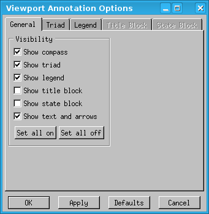

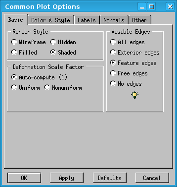

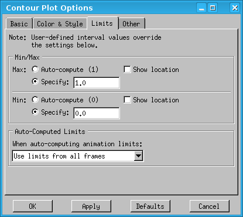

Figure 9.2: Viewport Annotation dialog on the left hand side, the Common Plot Options window in the middle and Contour Plot Options dialog on the right hand side.

To show or hide graphical objects like the compass in the viewport, open the Viewport Annotation Options window by selecting `Viewport->Viewport Annotation Options` in the main menu.

Images of the model which are to be inserted in a thesis or paper should be saved as Encapsulated PostScript (.eps) files, to minimize losing image quality when scaling.

Remove all unwanted elements from the viewport using the Annotation Option window and select `File->Print` in the main menu. Select the current viewport and `eps` as output format in the Print window (cf. figure 9.3) and go to the Encapsulated PostScript Options window by clicking on the appropriate icon () to choose 300 dpi as resolution.

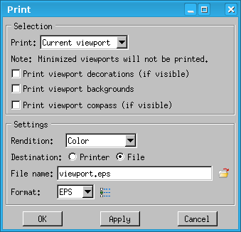

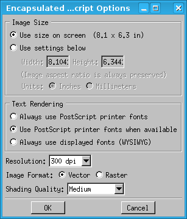

Figure 9.3: Print window and Encapsulated PostScript Options window with customized options.

The simulation can also be animated for any state variable, either by using the quick start symbol (), or by selecting `Animate->Time History` in the main menu. The animation can be saved by selecting `Animate->Save As`.

In case some variable states beneath the surface are of interest, a cut can be created. Open the View Cut Manager by selecting `Tools->View Cut->Manager` in the main menu or its icon () next to the Activate View Cut icon (). The principal planes are already available and can be selected or custom planes can be created.

## 9.2 History output

Plots can be created by using the history output. Open the History Output window by either selecting `Result->History Output` in the main menu, or by right clicking on `XYData` in the model tree, choosing `Create` and selecting `ODB history output` in the Create XYData window (cf. figure 9.4). As for field output variables, only the selected values in the model output requests can be chosen. To save a data set for plotting elsewhere, choose `Report->XY` in the main menu and select the XY Data to save.

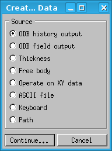

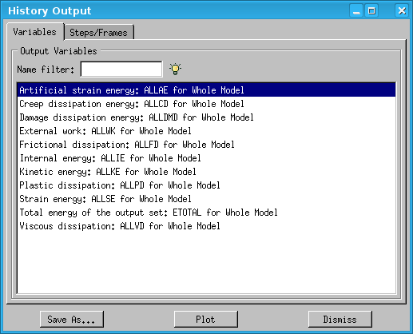

Figure 9.4: Create XY Data window on the left hand side and History Output window on the right hand side.

Sometimes it may be interesting not only to plot values over time, but over another variable. For every plot a `_temp_` variable will be created automatically in the model tree under `XYData`. The data can also be saved manually by `Save As...` from the History or Field Output window. Choose the variables and save their results, so that both entries are listed in the model tree under `XYData`.

Now select `Tools->XY Data->Create` in the main menu or right click on `XYData` in the model tree and choose `Create`. In the Create XYData window select `Operate on XY data`. Select the `combine()` Operator and double click on both XY data sets, so that something similar to `combine( "dataset1", "dataset2" )` is shown in the upper area. Now the data set can be plotted or saved.

# Bibliography

ABAQUS Inc., 2005. Abaqus/explicit: Advanced topics. Available at: http://imechanica.org/node/15260.

Dassault Systèmes, 2014. Abaqus 6.14 manual.

Overvelde, J.T.B., 2010. Learn abaqus script in one hour. Available at: http://bertoldi.seas.harvard.edu/files/bertoldi/files/learnabaqusscriptinonehour.pdf.

[^1]: The working directory can be changed by running Abaqus from the intended working folder from shell or by setting the working directory manually in the main menu `File->Set Work Directory`.
[^2]: The commands in the journal file can serve as a workflow example, executed in Abaqus or a compact way to store all model information. If only the finished model should be available, the model file `<model>.cae` or the input files `<model>.inp` do suffice.
[^3]: Abaqus will add the shown Python command for renaming the model to the journal file. From here on, all Python commands represent either journal entries or more readable versions of the discussed action(s) described in the preceding text.
[^4]: Abaqus doesn’t explicitly use units. Here, a length of 1 represents 1 m. The user has to take care of choosing the right unit system for all input values. Two possible unit systems are suggested in table 3.1.
[^5]: Regarding Python code: Abaqus usually references points, edges, … by its index number which is not very helpful in code. A better solution when using scripts is to use the `findAt`-function.
[^6]: Regarding Python code: To reference elements in the code more comfortably, we assign variable names at creation like `partPile` in line 28. If there is no assignment at creation time, it could also be done later on, e. g. `partPile = mdb.models['PileJackingModel'].parts['Pile'];`.
[^7]: Only one datum point per cutting plane may be necessary, if the option `Point & Normal` is chosen instead of `3 Points`.
[^8]: For good simulations, the soil volume has to be big enough, such that boundary effects do not influence the results of the pile-soil interaction significantly.
[^9]: Regarding Python code: Abaqus names elements by its type and an increasing number like `Datum pt-1`. For easy access in code, either rename the elements or assign variable names at its creation.
[^10]: Regarding Python code: Abaqus usually references sets/selections with a binary sequence masks by `getSequenceFromMask(('[#25b ]', ), )`. To select the correct geometry in code, sequences have to be generated (e. g. by iterating over elements as in line 82–86) to create such sets.
[^11]: The region of the Eulerian element can still be changed, if desired, but only after the initial assignment.
[^12]: Regarding Python code: There is no automatic set creation/selection when scripting. Therefore no new set like `Set-7` in figure 3.3 is created and the existing `setAll` is chosen for assignment.
[^13]: Regarding Python code: For easier future acces of both instances, variable names `instSoil` and `instPart` will be assigned in the code (line 133 and 135).
[^14]: Therefore it can be useful to use `(0.0, 0.0, 0.0)` as start vector and define the desired translation as end vector.
[^15]: CSYS: user defined coordinate system
[^16]: If this step had been done before creating an interaction, the property would already be available in the drop-down menu.
[^17]: If friction is to be modelled, the soil–pile interaction can be described by Coulomb’s law with a penalty method.
[^18]: The duration is also dimensionless, but in the unit system used for this example, it matches a second.
[^19]: It is equally valid to restrict all movement in the Initial step with one boundary condition and modify it whenerver something changes in any following step.
[^20]: Sometimes it may be useful to define the amount of seeds with the by number method.
[^21]: If the output database was created with an older version of Abaqus, it has to be upgraded first. If it was created with a more recent version, it can’t be opened.